# BTR Results Overview

09 August, 2024

# Energy CO2 Emissions

## Sector

### Model

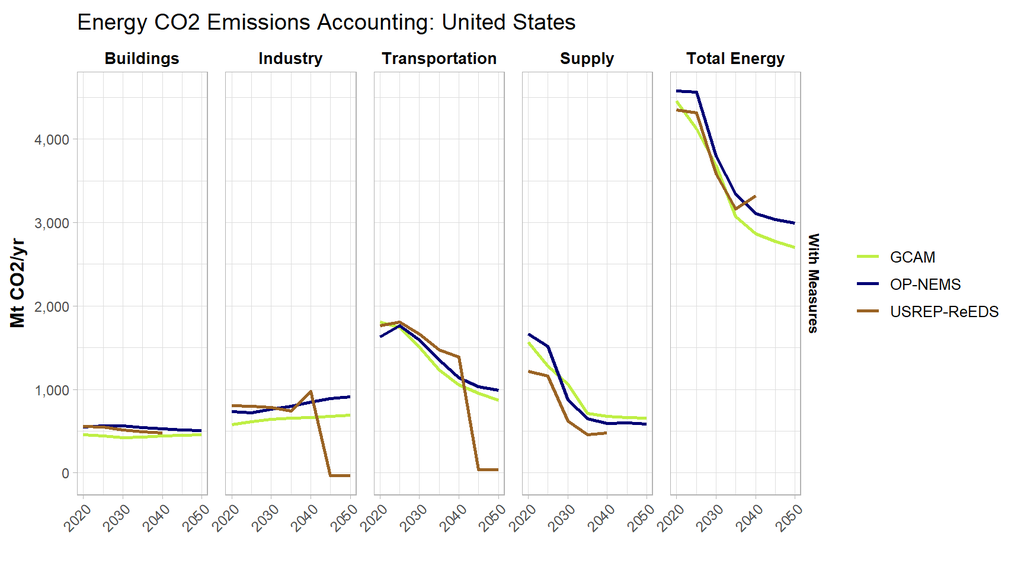

### Sector

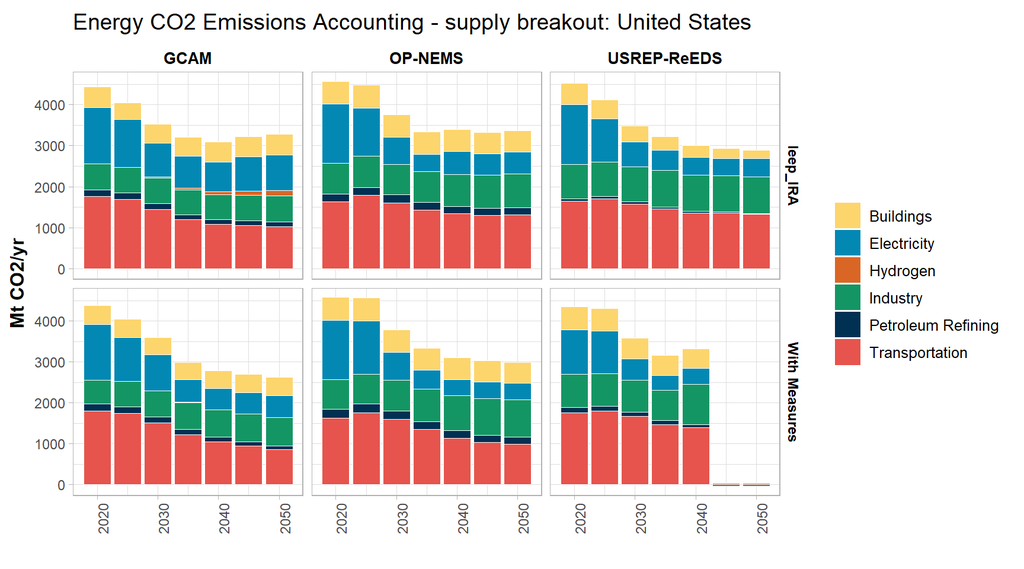

### Stats

In the “With Measures” scenarios, Energy CO<sub>2</sub> emissions reductions range by model from 2020 to 2040:

- GCAM: -36%
- OP-NEMS: -32%
- USREP-ReEDS: -24%

By sector, emissions reductions are estimate to change from 2020 to 2040:

- Buildings:
  - GCAM: -4%
  - OP-NEMS: -4%
  - USREP-ReEDS: -15%
- Industry:
  - GCAM: 14%
  - OP-NEMS: 15%
  - USREP-ReEDS: 21%
- Transportation:
  - GCAM: -42%
  - OP-NEMS: -30%
  - USREP-ReEDS: -21%

## Fuel

### Model

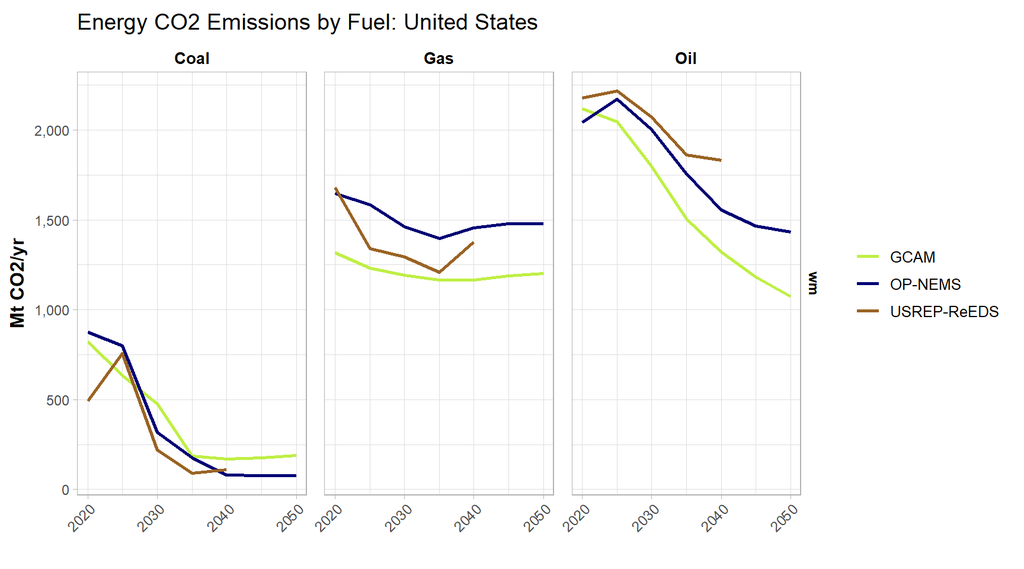

### Fuel

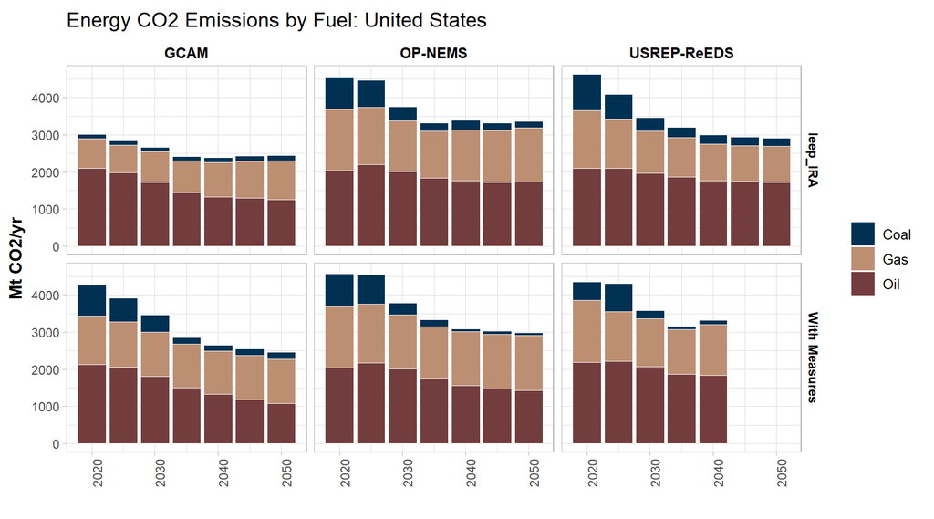

# Energy Consumption

## Final Energy

### Fuel

#### Fuel

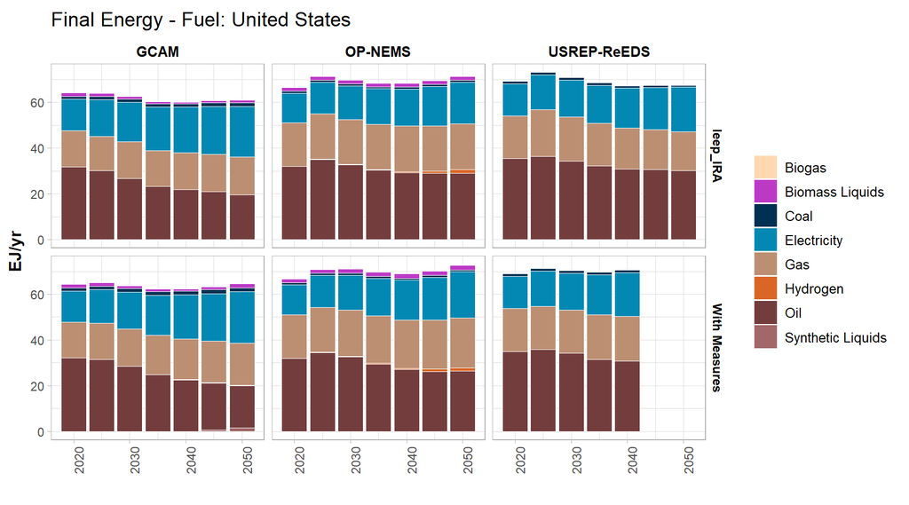

#### Model

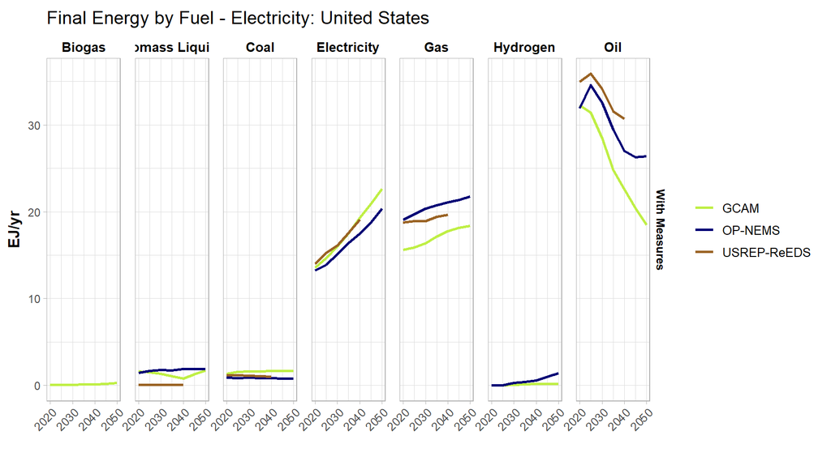

#### Model - Zoom

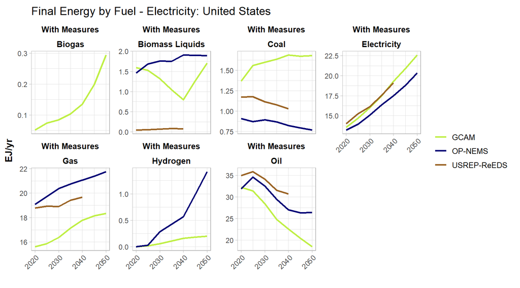

#### Stats

Energy consumption is estimated to change from 2020 to 2040:

- GCAM: -3%
- OP-NEMS: 3%
- USREP-ReEDS: 2%

By fuel-type, energy consumption is estimated to change from 2020 to 2040:

- Coal:
  - GCAM: 23%
  - OP-NEMS: -9%
  - USREP-ReEDS: -12%
- Electricity:
  - GCAM: 42%
  - OP-NEMS: 32%
  - USREP-ReEDS: 36%
- Gas:
  - GCAM: 14%
  - OP-NEMS: 10%
  - USREP-ReEDS: 5%
- Oil:
  - GCAM: -30%
  - OP-NEMS: -15%
  - USREP-ReEDS: -12%

### Sector

#### Model

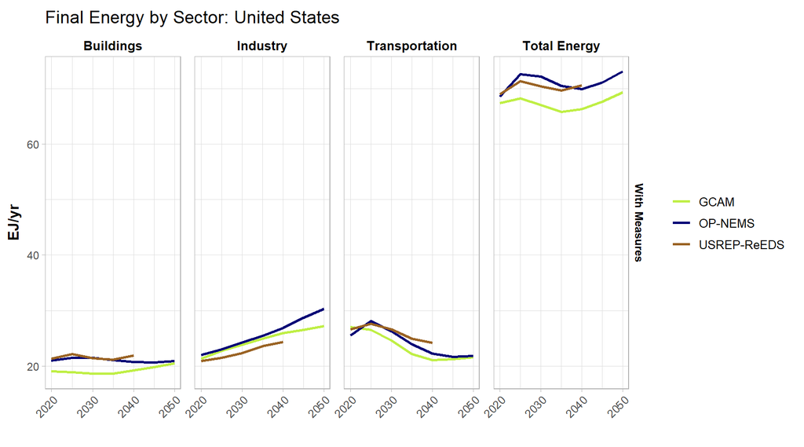

#### Sector

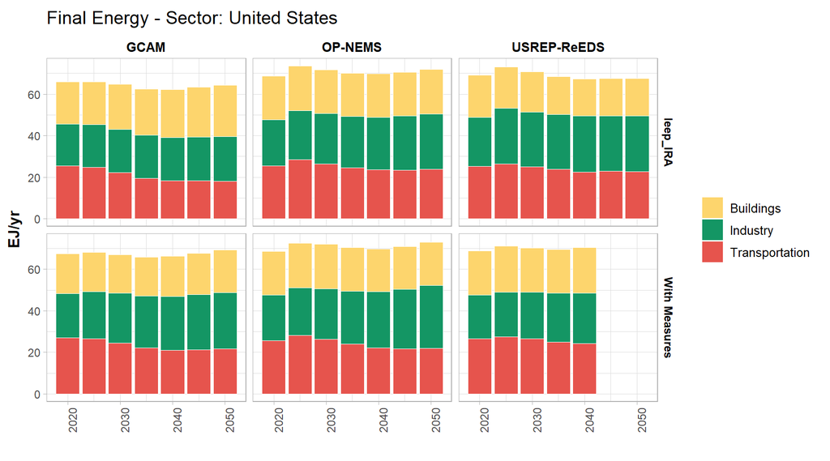

#### Stats

By sector, energy consumption is estimated to change from 2020 to 2040:

- Buildings:
  - GCAM: 1%
  - OP-NEMS: -1%
  - USREP-ReEDS: 3%
- Industry:
  - GCAM: 22%
  - OP-NEMS: 22%
  - USREP-ReEDS: 16%
- Transportation:
  - GCAM: -22%
  - OP-NEMS: -13%
  - USREP-ReEDS: -9%

## Sectoral Detail

### Buildings

#### Model

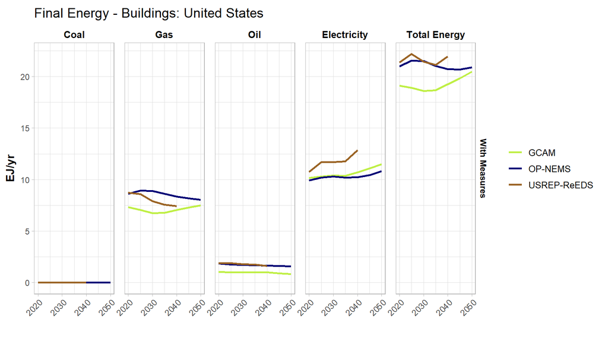

#### Buildings

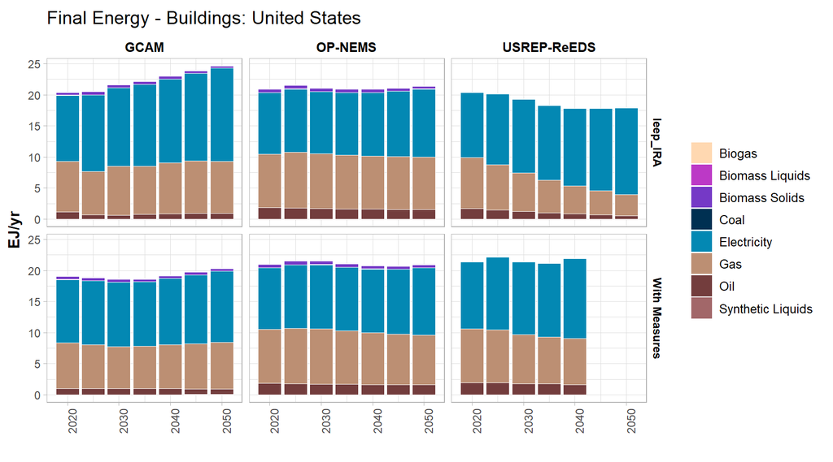

#### Residential by Model

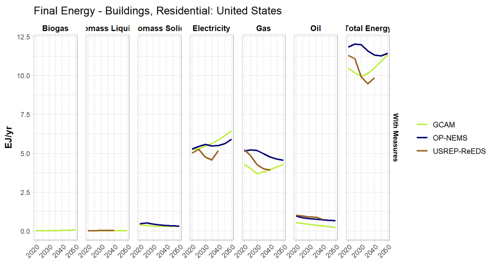

#### Residential

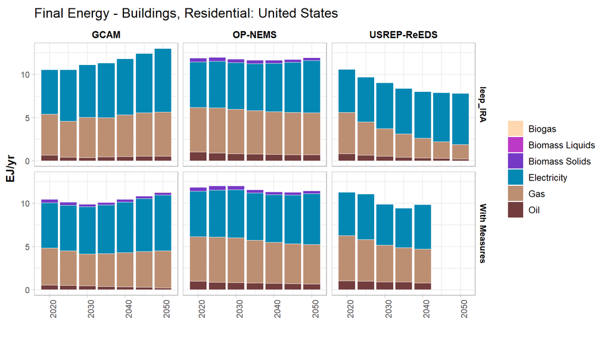

#### Commercial by Model

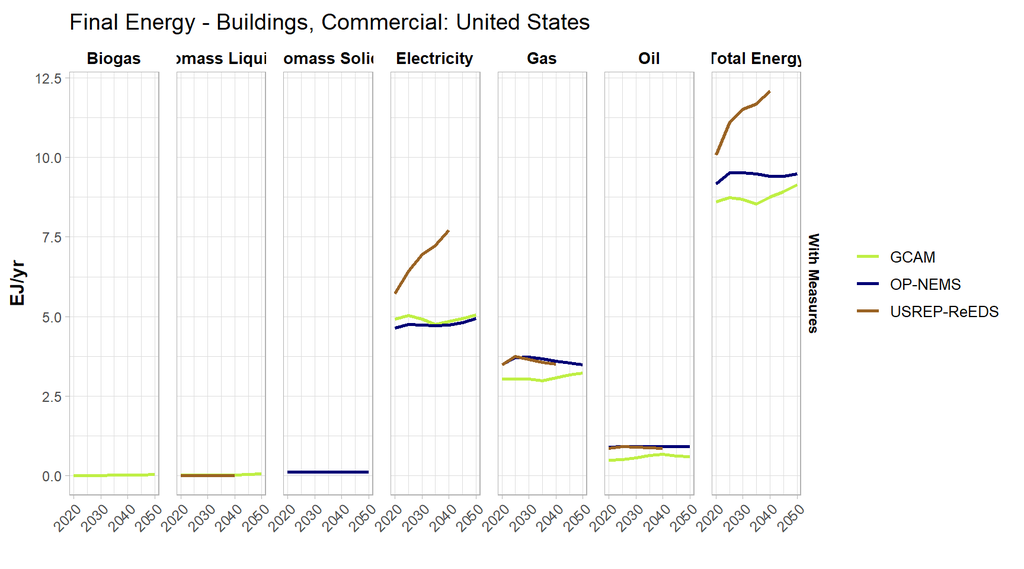

#### Commercial

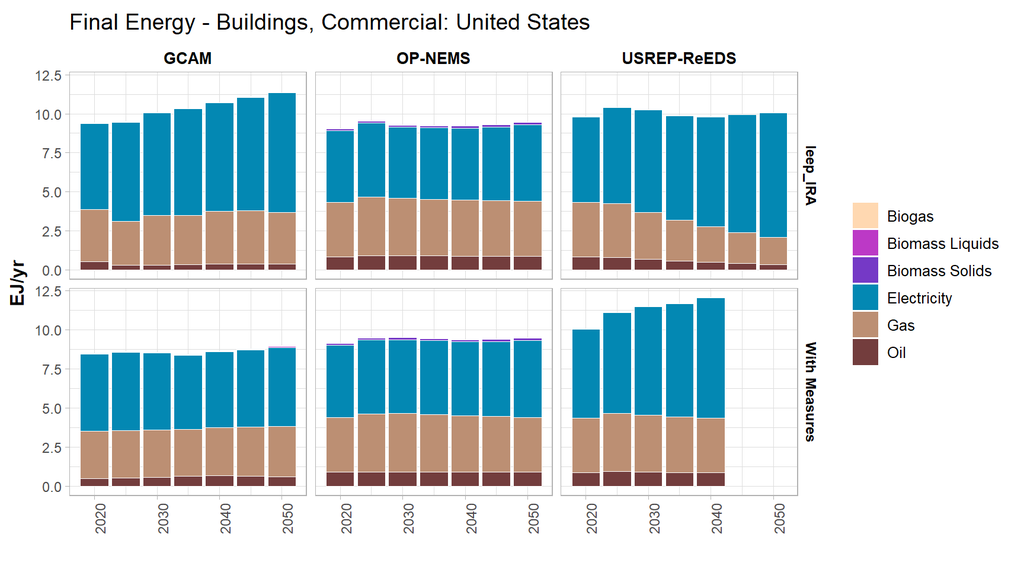

### Industry

#### Model

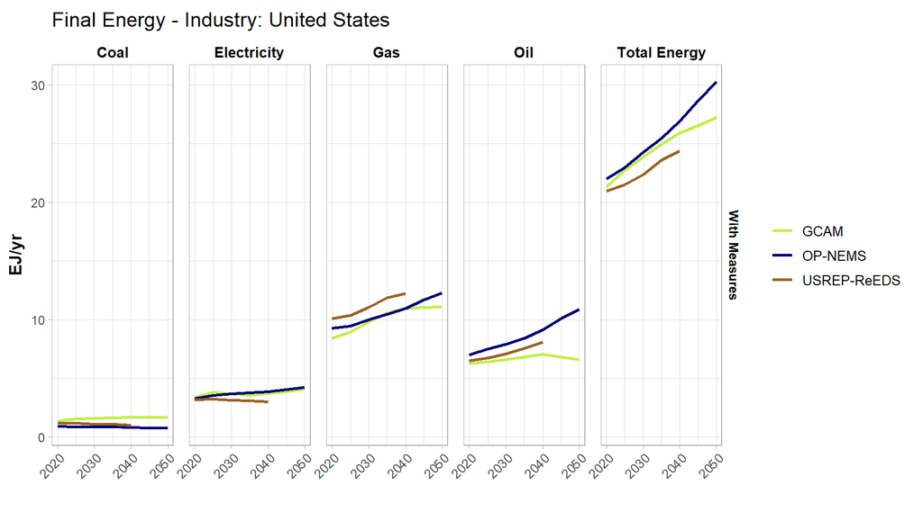

#### Industry

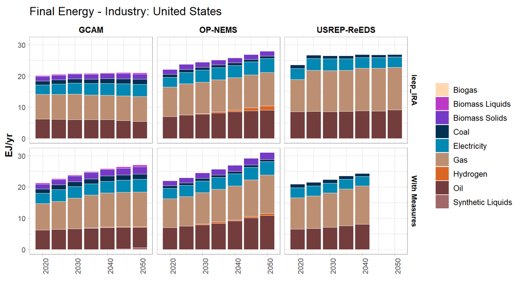

### Transportation

#### Model

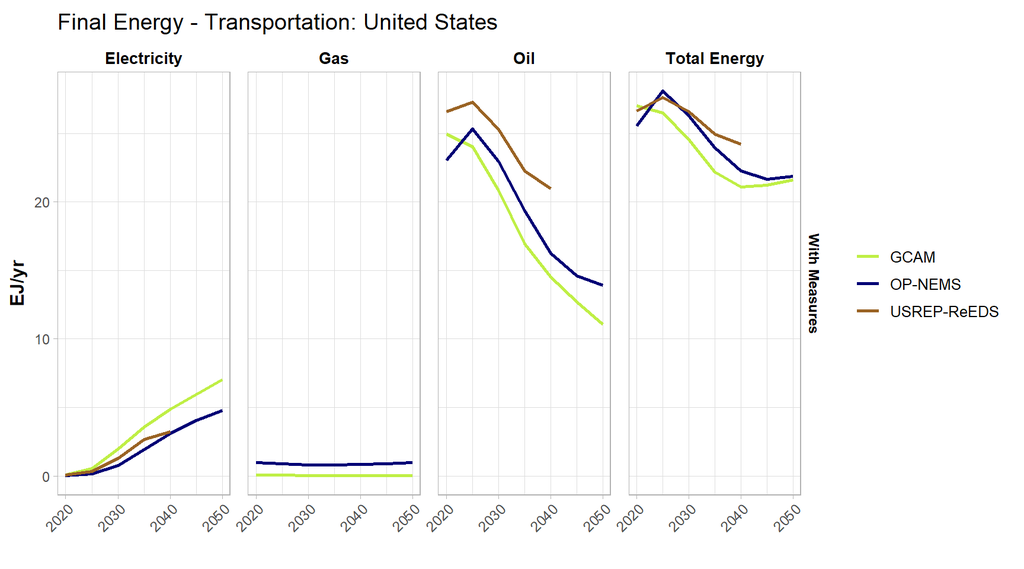

#### Transportation

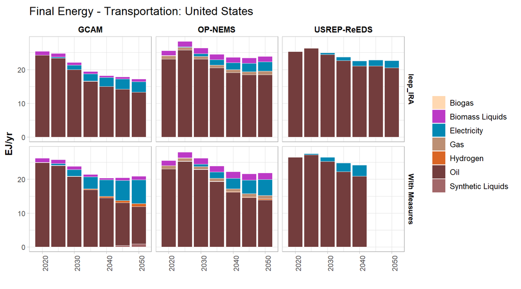

## Percent Electricity

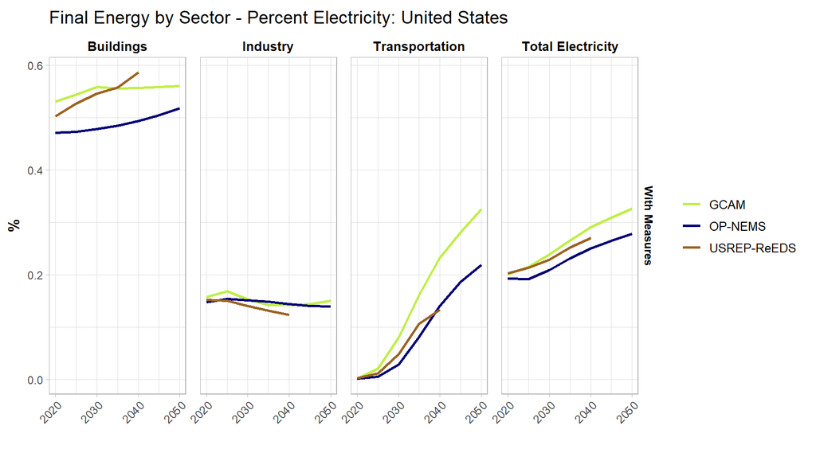

# Energy Production

## Secondary Energy

### Model

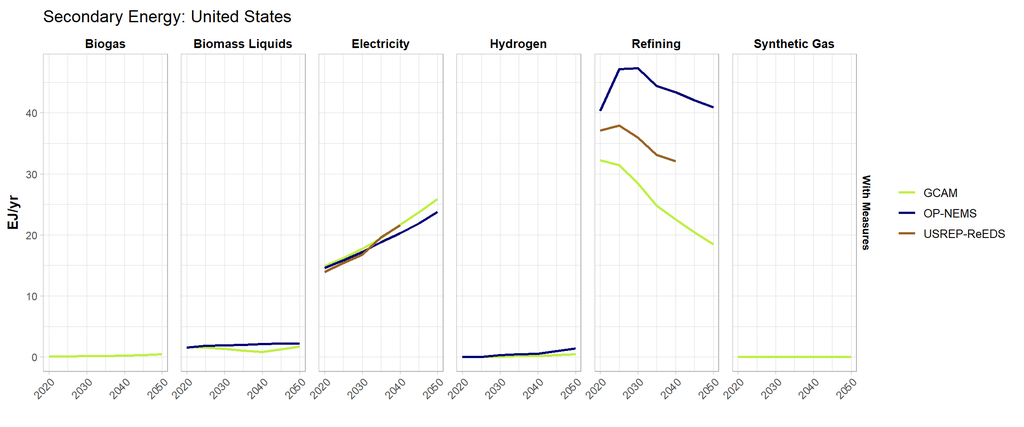

### Model - Zoom

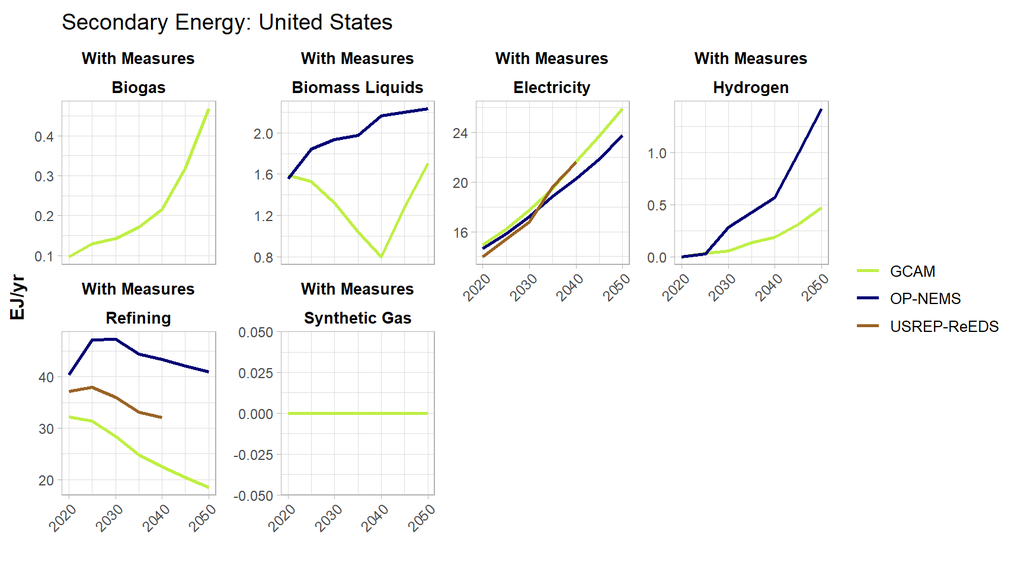

### Fuel

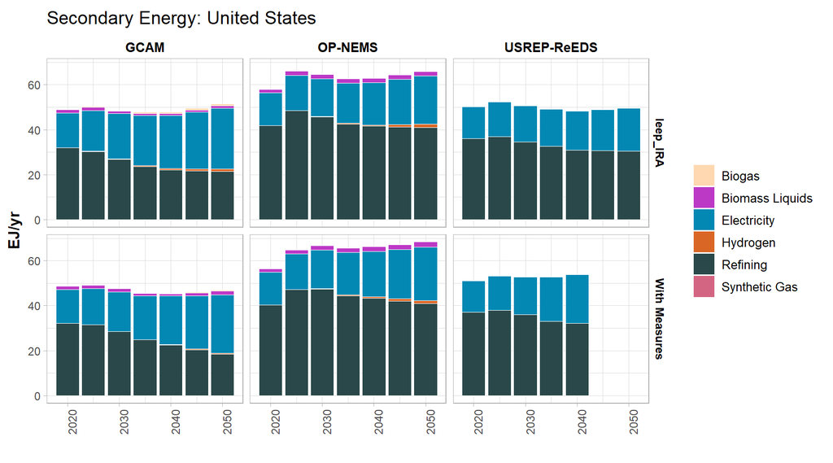

## Electricity Production

### Generation

#### Model

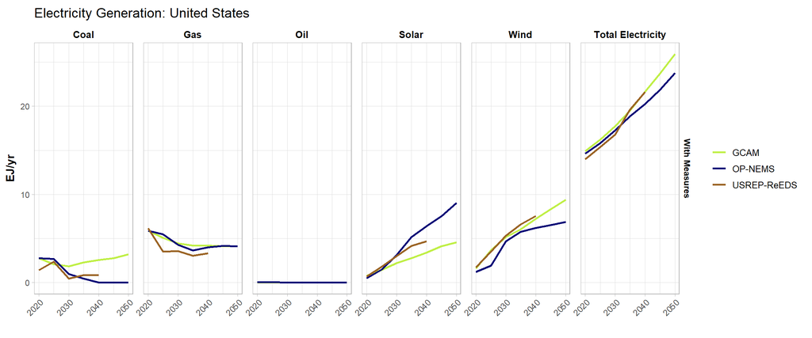

#### Model - Zoom

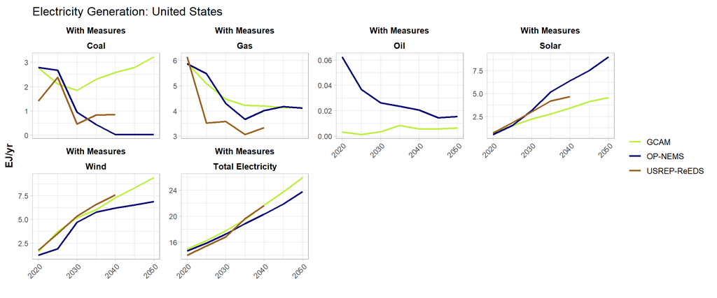

#### Generation

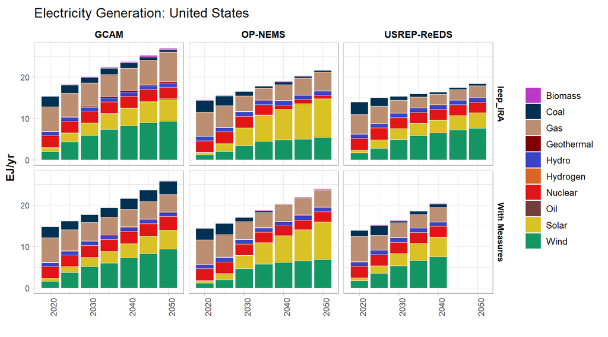

### Capacity

#### Model

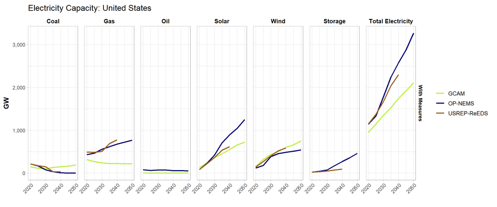

#### Model - Zoom

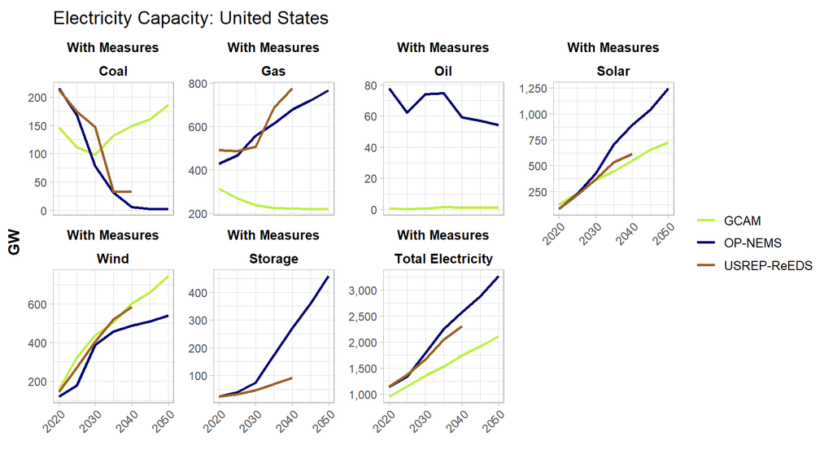

#### Capacity

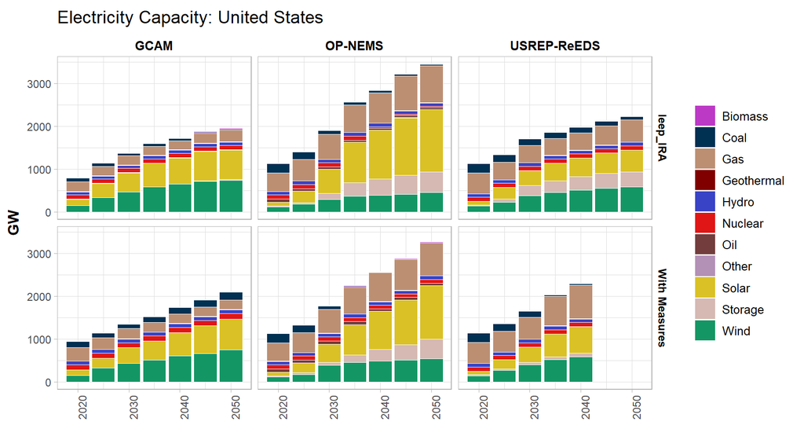

#### Stats

Electricity capacity is estimated to increase from 2020 to 2040:

- GCAM: 84%
- OP-NEMS: 126%
- USREP-ReEDS: 101%

## Combustion

### Generation

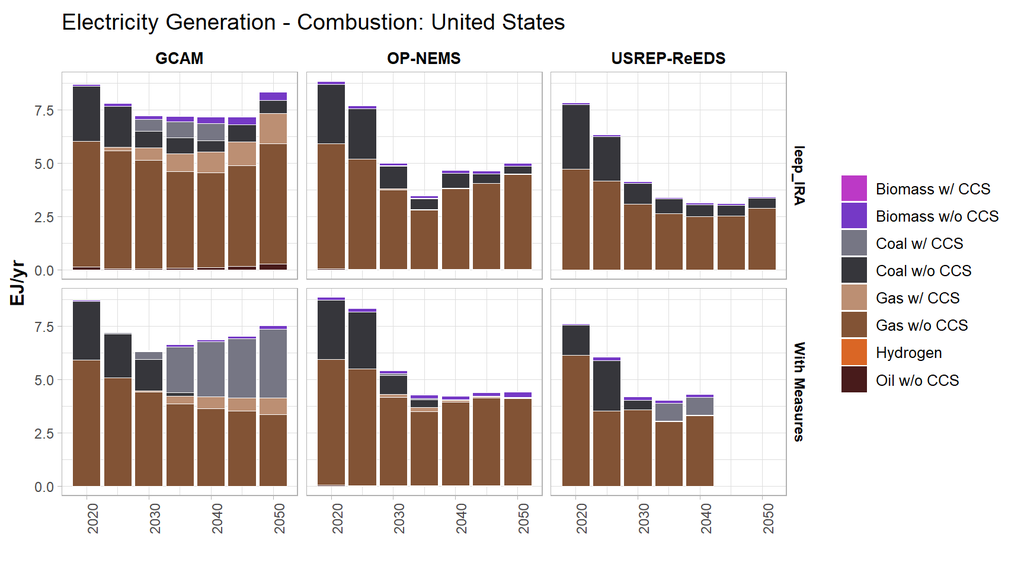

### Generation by Model

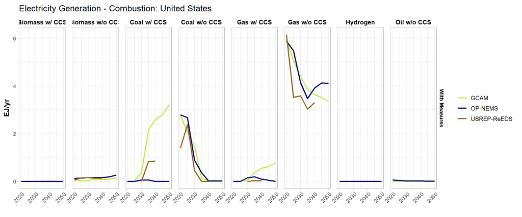

### Generation by Model - Zoom

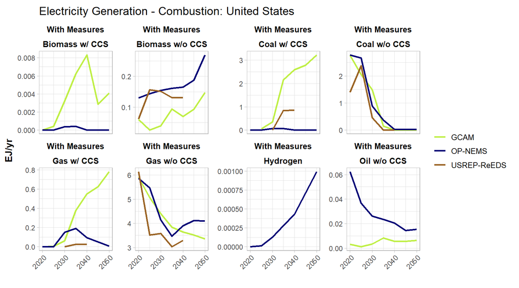